**ANN Training**

By Prof. Seungchul Lee  
http://iai.postech.ac.kr/  
Industrial AI Lab at POSTECH

Table of Contents

# 1. Recursive Algorithm

- One of the central ideas of computer science
- Depends on solutions to smaller instances of the same problem ( = subproblem)
- Function to call itself (it is impossible in the real world)

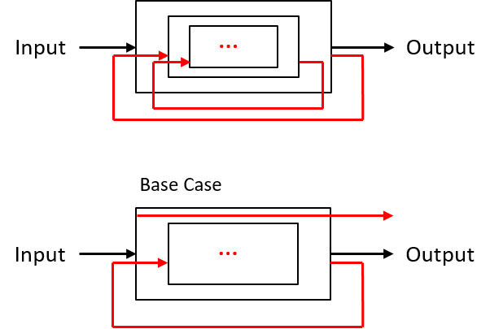

```python
%%html
<center><iframe src="https://www.youtube.com/embed/t4MSwiqfLaY?rel=0"
width="560" height="315" frameborder="0" allowfullscreen></iframe></center>
```

[video not shown]

- Factorial example

$$n ! = n \cdot (n-1) \cdots 2 \cdot 1$$

```python
n = 5

m = 1
for i in range(n):
    m = m*(i+1)

print(m)
```

```
120
```

```python
def fac(n):
    if n == 1:
        return 1
    else:
        return n*fac(n-1)
```

```python
# recursive

fac(5)
```

```
120
```

# 2. Dynamic Programming

- Dynamic Programming: general, powerful algorithm design technique
- Fibonacci numbers:

```python
# naive Fibonacci

def fib(n):
    if n <= 2:
        return 1
    else:
        return fib(n-1) + fib(n-2)
```

```python
fib(10)
```

```
55
```

```python
# Memorized DP Fibonacci

def mfib(n):
    global memo

    if memo[n-1] != 0:
        return memo[n-1]
    elif n <= 2:
        return 1
    else:
        memo[n-1] = mfib(n-1) + mfib(n-2)
        return memo[n-1]
```

```python
import numpy as np

n = 10
memo = np.zeros(n)
mfib(n)
```

```
55.0
```

```python
n = 30
%timeit fib(30)
```

```
172 ms ± 830 µs per loop (mean ± std. dev. of 7 runs, 10 loops each)
```

```python
memo = np.zeros(n)
%timeit mfib(30)
```

```
402 ns ± 3.18 ns per loop (mean ± std. dev. of 7 runs, 1000000 loops each)
```

# 3. Training Neural Networks

$=$ Learning or estimating weights and biases of multi-layer perceptron from training data

## 3.1. Optimization

**3 key components**

1. objective function $f(\cdot)$
2. decision variable or unknown $\omega$
3. constraints $g(\cdot)$

**In mathematical expression**

$$\begin{align*} \min_{\omega} \quad &f(\omega) \end{align*} $$

## 3.2. Loss Function

- Measures error between target values and predictions

$$ \min_{\omega} \sum_{i=1}^{m}\ell\left( h_{\omega}\left(x^{(i)}\right),y^{(i)}\right)$$

- Example
  - Squared loss (for regression): $$ \frac{1}{m} \sum_{i=1}^{m} \left(h_{\omega}\left(x^{(i)}\right) - y^{(i)}\right)^2 $$
  - Cross entropy (for classification): $$ -\frac{1}{m}\sum_{i=1}^{m}y^{(i)}\log\left(h_{\omega}\left(x^{(i)}\right)\right) + \left(1-y^{(i)}\right)\log\left(1-h_{\omega}\left(x^{(i)}\right)\right)$$

## 3.3. Learning

Learning weights and biases from data using gradient descent

$$\omega \Leftarrow \omega - \alpha \nabla_{\omega} \ell \left( h_{\omega}\left(x^{(i)}\right), y^{(i)} \right)$$

- $\frac{\partial \ell}{\partial \omega}$: too many computations are required for all $\omega$
- Structural constraints of NN:
  - Composition of functions
  - Chain rule
  - Dynamic programming

**Backpropagation**

- Forward propagation
  - the initial information propagates up to the hidden units at each layer and finally produces output
- Backpropagation
  - allows the information from the cost to flow backwards through the network in order to compute the gradients
- Chain Rule
  - Computing the derivative of the composition of functions
    - $\space f(g(x))' = f'(g(x))g'(x)$
    - $\space {dz \over dx} = {dz \over dy} \bullet {dy \over dx}$
    - $\space {dz \over dw} = ({dz \over dy} \bullet {dy \over dx}) \bullet {dx \over dw}$
    - $\space {dz \over du} = ({dz \over dy} \bullet {dy \over dx} \bullet {dx \over dw}) \bullet {dw \over du}$
- Backpropagation
  - Update weights recursively with memory

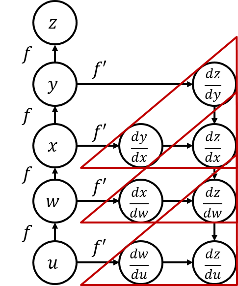

**Optimization procedure**

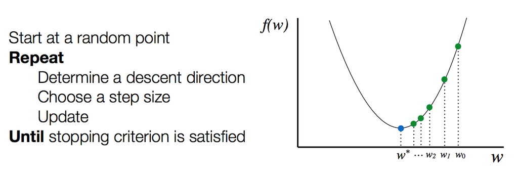

- It is not easy to numerically compute gradients in network in general.
  - The good news: people have already done all the "hardwork" of developing numerical solvers (or libraries)
  - There are a wide range of tools: $\color{Red}{\text{TensorFlow}}$

**Summary**

- Learning weights and biases from data using gradient descent

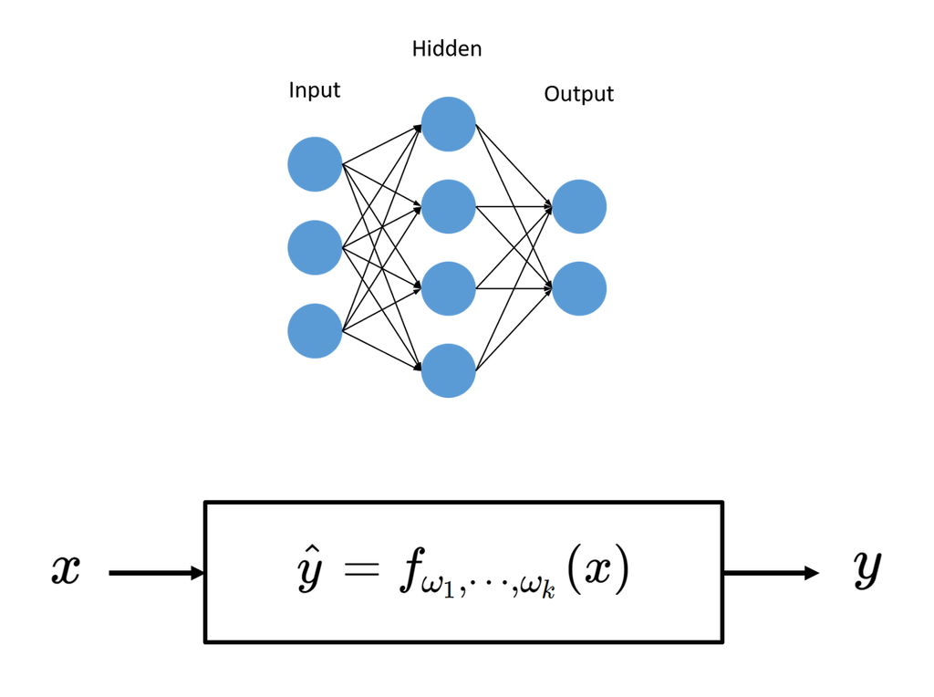

# 4. Other Tutorials

```python
%%html
<center><iframe src="https://www.youtube.com/embed/aircAruvnKk?rel=0"
width="560" height="315" frameborder="0" allowfullscreen></iframe></center>
```

[video not shown]

```python
%%html
<center><iframe src="https://www.youtube.com/embed/IHZwWFHWa-w?rel=0"
width="560" height="315" frameborder="0" allowfullscreen></iframe></center>
```

[video not shown]

```python
%%html
<center><iframe src="https://www.youtube.com/embed/Ilg3gGewQ5U?rel=0"
width="560" height="315" frameborder="0" allowfullscreen></iframe></center>
```

[video not shown]

```python
%%html
<center><iframe src="https://www.youtube.com/embed/tIeHLnjs5U8?rel=0"
width="560" height="315" frameborder="0" allowfullscreen></iframe></center>
```

[video not shown]

```python
%%javascript
$.getScript('https://kmahelona.github.io/ipython_notebook_goodies/ipython_notebook_toc.js')
```